# Notebook: Association rule

YiChun Sung (cd12631@gmail.com)

2017年7月10日

# 關聯規則Association rule

或稱連結分析Link analysis

- 項集(Itemset): 集合的概念 ex:二元項集{啤酒, 尿布}
- 連結規則(Association Rule):X(條件lhs)=>Y(連結結果rhs), 尿布→啤酒: 買了尿布的人也買了啤酒

> 假設10000個消費者中，購買尿布的1000個，購買啤酒的2000個，購買麵包的有500個，其中同時購買尿布和啤酒的有800個，同時購買尿布和麵包的有100個。
- 支援度(Support):

透過設定支援度最小設定值(minsup, Minimum Support)來選出支援度最好的項集。

假設支援度最小設定值訂為5%，{啤酒, 尿布}的支援度為800/10000 = 8%，{尿布, 麵包}則為100/10000 = 1%，{啤酒, 尿布}跨過門檻，故此項集為較好之項集。

- 可靠度(Confidence):

選出最好的連結規則。

假設可靠度最小設定值(minson, Minimum Confidence)為70%，尿布→啤酒可靠度為800/1000=80%，啤酒→尿布為800/2000=40%，故尿布→啤酒為較好的連結規則。

- 提升度(Lift):

lift值若=1 表示X, Y互相獨立，lift值越大(>1)連結性越強。尿布→啤酒的lift值為0.8/0.2 = 4

- 演算步驟:

選出超過支援度最小設定值的所有項集，然後在找出超過最小設定值可靠度的連結規則。

## 套件

使用arules套件。

```r
# install.packages("arules")
library(arules)
```

## 建模

`apriori()` : 建立連結模型的函數 `inspect()` : 觀察連結模型

### 取得資料

```r
data("Groceries") # arules套件內建的資料表
inspect(Groceries[1:10]) #看一下前10項
```

```
##      items
## [1]  {citrus fruit,
##       semi-finished bread,
##       margarine,
##       ready soups}
## [2]  {tropical fruit,
##       yogurt,
##       coffee}
## [3]  {whole milk}
## [4]  {pip fruit,
##       yogurt,
##       cream cheese ,
##       meat spreads}
## [5]  {other vegetables,
##       whole milk,
##       condensed milk,
##       long life bakery product}
## [6]  {whole milk,
##       butter,
##       yogurt,
##       rice,
##       abrasive cleaner}
## [7]  {rolls/buns}
## [8]  {other vegetables,
##       UHT-milk,
##       rolls/buns,
##       bottled beer,
##       liquor (appetizer)}
## [9]  {pot plants}
## [10] {whole milk,
##       cereals}
```

### 成果

Support設為0.01 confidence設為0.5

```r
rule0 <- apriori(Groceries,
                 parameter = list(support = 0.01,
                                  confidence = 0.5)
                 )
```

```
## Apriori
##
## Parameter specification:
##  confidence minval smax arem  aval originalSupport maxtime support minlen
##         0.5    0.1    1 none FALSE            TRUE       5    0.01      1
##  maxlen target   ext
##      10  rules FALSE
##
## Algorithmic control:
##  filter tree heap memopt load sort verbose
##     0.1 TRUE TRUE  FALSE TRUE    2    TRUE
##
## Absolute minimum support count: 98
##
## set item appearances ...[0 item(s)] done [0.00s].
## set transactions ...[169 item(s), 9835 transaction(s)] done [0.00s].
## sorting and recoding items ... [88 item(s)] done [0.00s].
## creating transaction tree ... done [0.00s].
## checking subsets of size 1 2 3 4 done [0.00s].
## writing ... [15 rule(s)] done [0.00s].
## creating S4 object  ... done [0.00s].
```

取前10條規則出來觀察，記得要觀察或是調用arules套件內的物件需要使用`inspect()`函數。

```r
df_rule0 <- inspect(rule0[1:10])
```

```
##      lhs                     rhs                   support confidence     lift
## [1]  {curd,
##       yogurt}             => {whole milk}       0.01006609  0.5823529 2.279125
## [2]  {other vegetables,
##       butter}             => {whole milk}       0.01148958  0.5736041 2.244885
## [3]  {other vegetables,
##       domestic eggs}      => {whole milk}       0.01230300  0.5525114 2.162336
## [4]  {yogurt,
##       whipped/sour cream} => {whole milk}       0.01087951  0.5245098 2.052747
## [5]  {other vegetables,
##       whipped/sour cream} => {whole milk}       0.01464159  0.5070423 1.984385
## [6]  {pip fruit,
##       other vegetables}   => {whole milk}       0.01352313  0.5175097 2.025351
## [7]  {citrus fruit,
##       root vegetables}    => {other vegetables} 0.01037112  0.5862069 3.029608
## [8]  {tropical fruit,
##       root vegetables}    => {other vegetables} 0.01230300  0.5845411 3.020999
## [9]  {tropical fruit,
##       root vegetables}    => {whole milk}       0.01199797  0.5700483 2.230969
## [10] {tropical fruit,
##       yogurt}             => {whole milk}       0.01514997  0.5173611 2.024770
```

把他做成table比較好展示

```r
library(knitr)
table_rule0 <-data.frame(df_rule0)
table_result <- data.frame(lhs_rule0 = as.vector(df_rule0[[1]]),
                          rule_direction = as.vector(df_rule0[[2]]),
                          rhs__rule0 = as.vector(df_rule0[[3]]),
                          support__rule0 = as.numeric(as.vector(df_rule0[[4]])),
                          confidence__rule0 = as.numeric(as.vector(df_rule0[[5]])),
                          lift__rule0 = as.numeric(as.vector(df_rule0[[6]]))
                          )

#kable(table_result)
```

利用`sort()`去控制升昇冪排序

```r
rule1 <- sort(rule0, by = "support") # 利用support去排序
rule2 <- sort(rule0, by = "confidence") # 利用Confidence去排序
rule3 <- sort(rule0, by = "lift") # 利用lift去排序
inspect(rule1[1:5])
```

```
##     lhs                     rhs             support confidence     lift
## [1] {other vegetables,
##      yogurt}             => {whole milk} 0.02226741  0.5128806 2.007235
## [2] {tropical fruit,
##      yogurt}             => {whole milk} 0.01514997  0.5173611 2.024770
## [3] {other vegetables,
##      whipped/sour cream} => {whole milk} 0.01464159  0.5070423 1.984385
## [4] {root vegetables,
##      yogurt}             => {whole milk} 0.01453991  0.5629921 2.203354
## [5] {pip fruit,
##      other vegetables}   => {whole milk} 0.01352313  0.5175097 2.025351
```

### 另一個範例

看一下通常是那些演員會和James Cameron導演合作

```r
movie_test <- read.csv('c:/R_Application/Machine Learning/data/Movie.csv')

rule_movie <- apriori(movie_test,
                      parameter=list(supp=0.001, conf=0.4, minlen=3),
                      appearance = list(default="lhs",
                                        rhs=c("d=James Cameron"))
                )
```

```
## Apriori
##
## Parameter specification:
##  confidence minval smax arem  aval originalSupport maxtime support minlen
##         0.4    0.1    1 none FALSE            TRUE       5   0.001      3
##  maxlen target   ext
##      10  rules FALSE
##
## Algorithmic control:
##  filter tree heap memopt load sort verbose
##     0.1 TRUE TRUE  FALSE TRUE    2    TRUE
##
## Absolute minimum support count: 0
##
## set item appearances ...[1 item(s)] done [0.00s].
## set transactions ...[50 item(s), 22 transaction(s)] done [0.00s].
## sorting and recoding items ... [50 item(s)] done [0.00s].
## creating transaction tree ... done [0.00s].
## checking subsets of size 1 2 3 done [0.00s].
## writing ... [7 rule(s)] done [0.00s].
## creating S4 object  ... done [0.00s].
```

```r
inspect(rule_movie)
```

```
##     lhs                       rhs                  support confidence lift
## [1] {a1=CCH Pounder,
##      a2=Joel David Moore}  => {d=James Cameron} 0.04545455          1 2.75
## [2] {a1=Joe Morton,
##      a2=Jenette Goldstein} => {d=James Cameron} 0.04545455          1 2.75
## [3] {a1=Jamie Lee Curtis,
##      a2=Tia Carrere}       => {d=James Cameron} 0.04545455          1 2.75
## [4] {a1=Michael Biehn,
##      a2=Todd Graff}        => {d=James Cameron} 0.04545455          1 2.75
## [5] {a1=Michael Biehn,
##      a2=Carrie Henn}       => {d=James Cameron} 0.04545455          1 2.75
## [6] {a1=Michael Biehn,
##      a2=Brian Thompson}    => {d=James Cameron} 0.04545455          1 2.75
## [7] {a1=Leonardo DiCaprio,
##      a2=Kate Winslet}      => {d=James Cameron} 0.09090909          1 2.75
```

## 視覺化

R裡面還有另一個套件arulesViz，將連結分析視覺化。

- 觀察每條規則的三項指標分布情況:

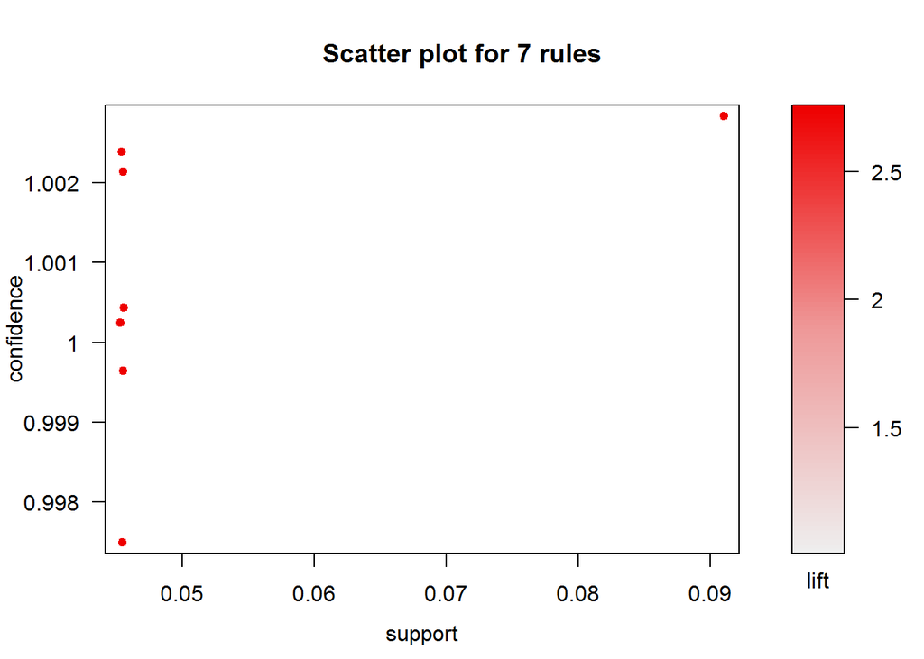

```r
library(arulesViz)
plot(rule_movie)
```

- 規則視覺化之一

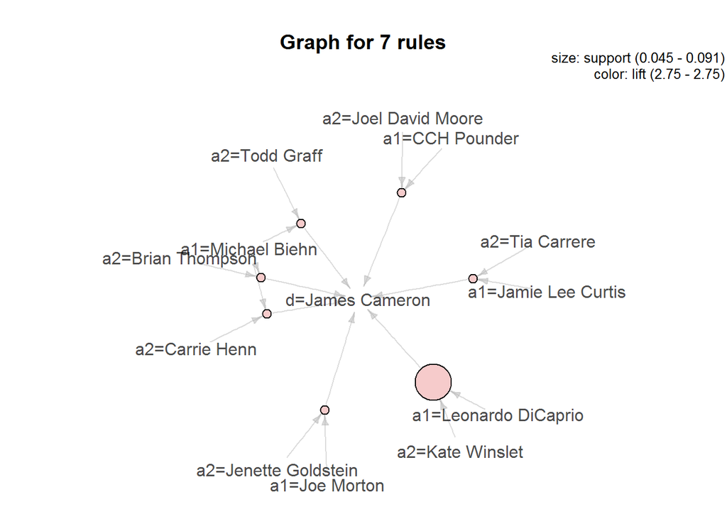

```r
plot(rule_movie, method="graph", control=list(type="items"))
```

- 規則視覺化之二

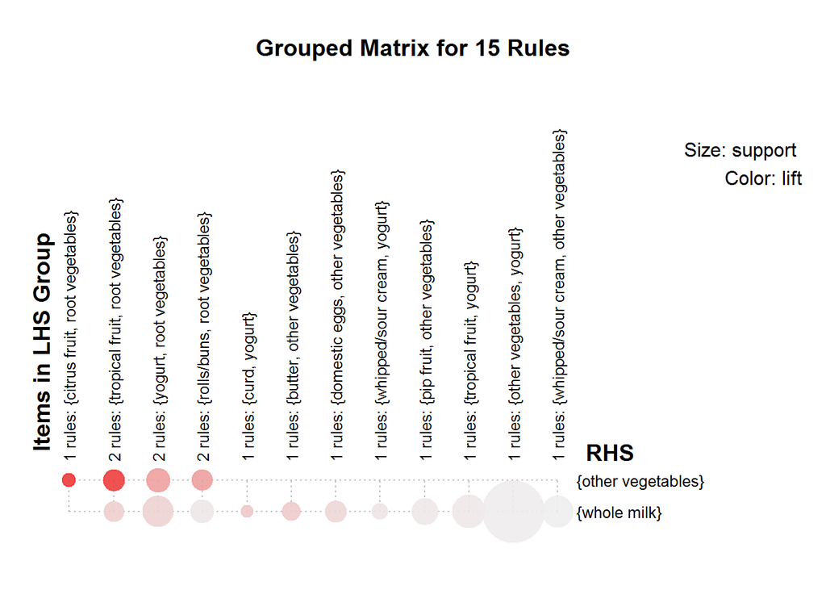

```r
plot(rule0, method="grouped")
```

## Reference

[R筆記–關聯式規則](http://www.rpubs.com/skydome20/R-Note6-Apriori-DecisionTree)

http://mhahsler.github.io/arules/